# Проект Предсказание уровня удовлетворенности и вероятности увольнения сотрудника - git

```python
!pip install phik -q
```

```python
!pip install shap -q
```

```python
import warnings
import pandas as pd
import numpy as np
import shap
from termcolor import colored # цвет
from matplotlib import pyplot as plt # графики
import seaborn as sns # графики
from scipy.stats import pearsonr
import phik # расчет коэффициентов корреляции
import copy

# загружаем классы для подготовки данных
from sklearn.preprocessing import (
    OneHotEncoder
    ,OrdinalEncoder
    ,StandardScaler
    ,MinMaxScaler
    ,RobustScaler
    ,FunctionTransformer
)

from sklearn.compose import ColumnTransformer
from sklearn.preprocessing import LabelEncoder
from sklearn.cluster import KMeans # метод кластеризации
from sklearn.impute import SimpleImputer # загружаем класс для работы с пропусками
from sklearn.model_selection import RandomizedSearchCV, train_test_split, GridSearchCV, KFold, StratifiedKFold  # импортируем класс RandomizedSearchCV

# загружаем нужные модели
from sklearn.linear_model import LinearRegression
from sklearn.neighbors import KNeighborsRegressor
from sklearn.tree import DecisionTreeRegressor
from sklearn.ensemble import RandomForestRegressor
from sklearn.svm import SVC
from sklearn.neighbors import KNeighborsClassifier
from sklearn.tree import DecisionTreeClassifier
from sklearn.ensemble import HistGradientBoostingRegressor


# загружаем класс pipeline
from sklearn.pipeline import Pipeline

# анализ эффективности модели
from sklearn.metrics import (
 roc_auc_score # загружаем функцию для работы с метриками
 ,mean_absolute_error # расчет ошибки
 ,r2_score # расчет ошибки
 ,mean_squared_error # импорт MSE для RMSE аргумент функции squared = False
 ,confusion_matrix # матрица ошибок (первый/второй год)
 ,accuracy_score # проверка ошибки логистической регрессии
 ,recall_score # ошибки второго рода
 ,precision_score # Ошибки первого рода
 ,mean_absolute_percentage_error # SMAPE
 ,make_scorer
)

from scipy.stats import ttest_ind, mannwhitneyu
# Проверка нормальности распределения (можно использовать тест Шапиро-Уилка)
from scipy.stats import shapiro
```

# Задача 1: предсказание уровня удовлетворённости сотрудника

- Необходимо сделать обработку данных, выявить зависимости и сделать обработку данных
- Необходимо обучить две модели, для предсказания уровня удовлетверенности сотрудников

## Загрузка данных

```python
# # Отключение всех предупреждений
warnings.filterwarnings('ignore')

# Или отключение определенных типов предупреждений
# Например, игнорирование предупреждений от модуля sklearn
warnings.filterwarnings('ignore', category=UserWarning, module='sklearn')
```

```python
train_job_satisfaction_rate = pd.read_csv('train_job_satisfaction_rate.csv')
test_features = pd.read_csv('test_features.csv')
test_target_job_satisfaction_rate = pd.read_csv('test_target_job_satisfaction_rate.csv')
```

```python
# Изменение толщины текста
def big_bold_text(text):
    return colored(text, attrs=['bold'])
```

```python
#Создадим словарь соответствия фрейма и его имени
dictionary_with_frames ={
    'train_job_satisfaction_rate': train_job_satisfaction_rate,
    'test_features': test_features,
    'test_target_job_satisfaction_rate': test_target_job_satisfaction_rate
}
```

## Предобработка данных

### Проверка на наличие дубликатов, пропусков. Вывод формата данных в столбцах, структуры таблицы и наименование столбцов

**Преобразуем наименование столбцов**

```python
for row in dictionary_with_frames:
    dictionary_with_frames[row].columns = dictionary_with_frames[row].columns.str.lower()
    dictionary_with_frames[row].columns = dictionary_with_frames[row].columns.str.replace(' ', '_', regex=True)
```

```python
#Функция тестировани данных
def test_df (dictionary_with_frames_col):
    for row in dictionary_with_frames_col:
        print(big_bold_text('Таблица: '),row)
        print(big_bold_text('Количество дубликатов: '),dictionary_with_frames[row].duplicated().sum())
        if dictionary_with_frames[row].duplicated().sum()>0:
            print('')
            print(big_bold_text('Строки с дубликатами:'))
            display(dictionary_with_frames[row].loc[dictionary_with_frames[row].duplicated()==True])
        print('')
        print(big_bold_text('Информация по таблице\n'))
        dictionary_with_frames[row].info()
        print('')
        print(big_bold_text('Количество пропусков:\n'))
        print(dictionary_with_frames[row].isna().sum())
        print('')
        print(big_bold_text('Вывод первых 5 строк из таблицы\n'))
        display(dictionary_with_frames[row].head(5))
        print(big_bold_text('_____________________________________________________________________________________________________'))
        print('')
test_df(dictionary_with_frames)
```

```
Таблица:  train_job_satisfaction_rate
Количество дубликатов:  0

Информация по таблице

<class 'pandas.core.frame.DataFrame'>
RangeIndex: 4000 entries, 0 to 3999
Data columns (total 10 columns):
 #   Column                 Non-Null Count  Dtype
---  ------                 --------------  -----
 0   id                     4000 non-null   int64
 1   dept                   3994 non-null   object
 2   level                  3996 non-null   object
 3   workload               4000 non-null   object
 4   employment_years       4000 non-null   int64
 5   last_year_promo        4000 non-null   object
 6   last_year_violations   4000 non-null   object
 7   supervisor_evaluation  4000 non-null   int64
 8   salary                 4000 non-null   int64
 9   job_satisfaction_rate  4000 non-null   float64
dtypes: float64(1), int64(4), object(5)
memory usage: 312.6+ KB

Количество пропусков:

id                       0
dept                     6
level                    4
workload                 0
employment_years         0
last_year_promo          0
last_year_violations     0
supervisor_evaluation    0
salary                   0
job_satisfaction_rate    0
dtype: int64

Вывод первых 5 строк из таблицы
```

|  | id | dept | level | workload | employment_years | last_year_promo | last_year_violations | supervisor_evaluation | salary | job_satisfaction_rate |
| --- | --- | --- | --- | --- | --- | --- | --- | --- | --- | --- |
| 0 | 155278 | sales | junior | medium | 2 | no | no | 1 | 24000 | 0.58 |
| 1 | 653870 | hr | junior | high | 2 | no | no | 5 | 38400 | 0.76 |
| 2 | 184592 | sales | junior | low | 1 | no | no | 2 | 12000 | 0.11 |
| 3 | 171431 | technology | junior | low | 4 | no | no | 2 | 18000 | 0.37 |
| 4 | 693419 | hr | junior | medium | 1 | no | no | 3 | 22800 | 0.20 |

```
_____________________________________________________________________________________________________

Таблица:  test_features
Количество дубликатов:  0

Информация по таблице

<class 'pandas.core.frame.DataFrame'>
RangeIndex: 2000 entries, 0 to 1999
Data columns (total 9 columns):
 #   Column                 Non-Null Count  Dtype
---  ------                 --------------  -----
 0   id                     2000 non-null   int64
 1   dept                   1998 non-null   object
 2   level                  1999 non-null   object
 3   workload               2000 non-null   object
 4   employment_years       2000 non-null   int64
 5   last_year_promo        2000 non-null   object
 6   last_year_violations   2000 non-null   object
 7   supervisor_evaluation  2000 non-null   int64
 8   salary                 2000 non-null   int64
dtypes: int64(4), object(5)
memory usage: 140.8+ KB

Количество пропусков:

id                       0
dept                     2
level                    1
workload                 0
employment_years         0
last_year_promo          0
last_year_violations     0
supervisor_evaluation    0
salary                   0
dtype: int64

Вывод первых 5 строк из таблицы
```

|  | id | dept | level | workload | employment_years | last_year_promo | last_year_violations | supervisor_evaluation | salary |
| --- | --- | --- | --- | --- | --- | --- | --- | --- | --- |
| 0 | 485046 | marketing | junior | medium | 2 | no | no | 5 | 28800 |
| 1 | 686555 | hr | junior | medium | 1 | no | no | 4 | 30000 |
| 2 | 467458 | sales | middle | low | 5 | no | no | 4 | 19200 |
| 3 | 418655 | sales | middle | low | 6 | no | no | 4 | 19200 |
| 4 | 789145 | hr | middle | medium | 5 | no | no | 5 | 40800 |

```
_____________________________________________________________________________________________________

Таблица:  test_target_job_satisfaction_rate
Количество дубликатов:  0

Информация по таблице

<class 'pandas.core.frame.DataFrame'>
RangeIndex: 2000 entries, 0 to 1999
Data columns (total 2 columns):
 #   Column                 Non-Null Count  Dtype
---  ------                 --------------  -----
 0   id                     2000 non-null   int64
 1   job_satisfaction_rate  2000 non-null   float64
dtypes: float64(1), int64(1)
memory usage: 31.4 KB

Количество пропусков:

id                       0
job_satisfaction_rate    0
dtype: int64

Вывод первых 5 строк из таблицы
```

|  | id | job_satisfaction_rate |
| --- | --- | --- |
| 0 | 130604 | 0.74 |
| 1 | 825977 | 0.75 |
| 2 | 418490 | 0.60 |
| 3 | 555320 | 0.72 |
| 4 | 826430 | 0.08 |

```
_____________________________________________________________________________________________________
```

**Вывод:**

Дубликатов нет, есть пропуски в данных в таблице **train_job_satisfaction_rate** и **test_features** далее подумаем, как нам необходимо обработать данные пропуски

Посмотрим на пропуски данных в наших df и подумаем, стоит ли удалять данные строки из выборки. Начнем с тренировочных данных

```python
train_job_satisfaction_rate.query('(dept.isnull() | level.isnull())')
```

|  | id | dept | level | workload | employment_years | last_year_promo | last_year_violations | supervisor_evaluation | salary | job_satisfaction_rate |
| --- | --- | --- | --- | --- | --- | --- | --- | --- | --- | --- |
| 1209 | 631073 | sales | NaN | medium | 1 | no | no | 4 | 27600 | 0.66 |
| 1469 | 416327 | sales | NaN | low | 1 | no | no | 5 | 18000 | 0.73 |
| 1526 | 694746 | NaN | junior | medium | 5 | no | no | 4 | 21600 | 0.62 |
| 1630 | 814624 | NaN | junior | medium | 3 | no | no | 4 | 24000 | 0.88 |
| 1633 | 475114 | NaN | junior | high | 4 | no | no | 4 | 31200 | 0.63 |
| 1745 | 135043 | sales | NaN | medium | 1 | no | no | 3 | 26400 | 0.30 |
| 2522 | 998838 | sales | NaN | medium | 1 | no | no | 5 | 27600 | 0.71 |
| 2781 | 497243 | NaN | junior | medium | 1 | no | no | 3 | 26400 | 0.28 |
| 2975 | 168668 | NaN | junior | low | 3 | no | no | 4 | 18000 | 0.88 |
| 3866 | 641150 | NaN | junior | low | 3 | no | yes | 4 | 12000 | 0.54 |

```python
test_features.query('(dept.isnull() | level.isnull())')
```

|  | id | dept | level | workload | employment_years | last_year_promo | last_year_violations | supervisor_evaluation | salary |
| --- | --- | --- | --- | --- | --- | --- | --- | --- | --- |
| 191 | 609865 | NaN | junior | medium | 1 | no | no | 1 | 20400 |
| 312 | 471990 | sales | NaN | low | 1 | no | no | 3 | 12000 |
| 1196 | 832342 | NaN | junior | medium | 1 | no | no | 4 | 28800 |

**Проведем анализ категориальных данных**

```
Таблица:  train_job_satisfaction_rate

Категориальный признак: dept
```

[figure not shown]

```
Категориальный признак: level
```

[figure not shown]

```
Категориальный признак: workload
```

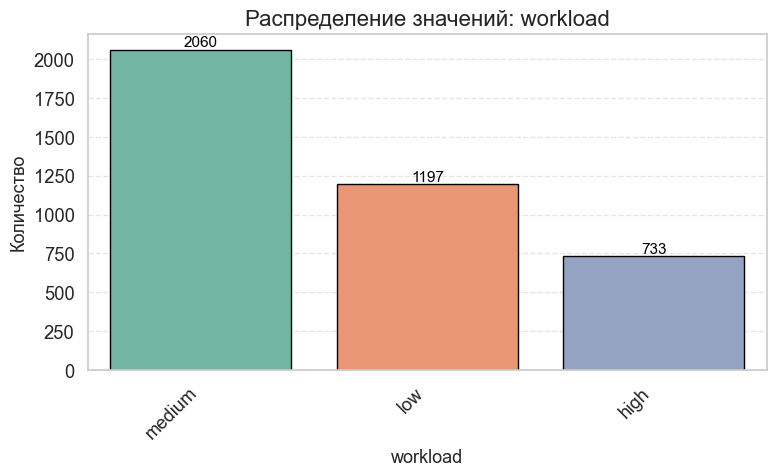

```
Категориальный признак: last_year_promo
```

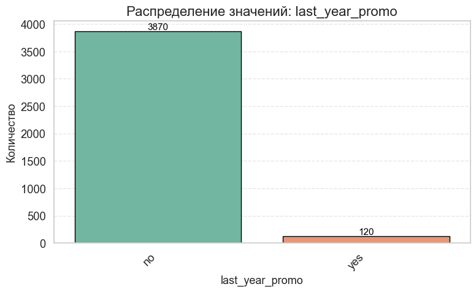

```
Категориальный признак: last_year_violations
```

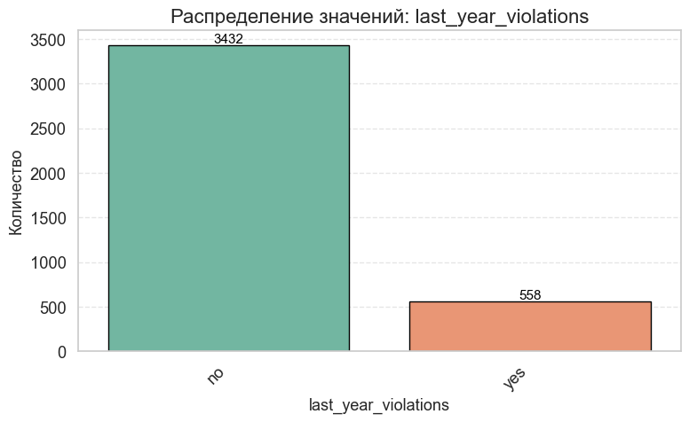

```
Таблица:  test_features

Категориальный признак: dept
```

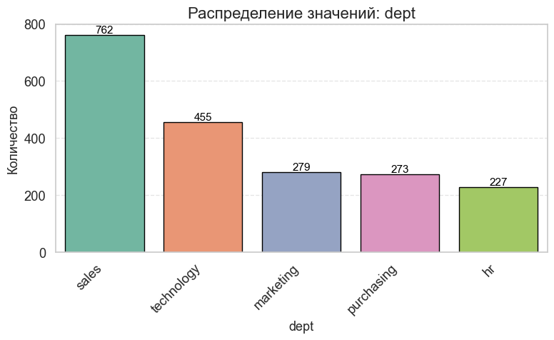

```
Категориальный признак: level
```

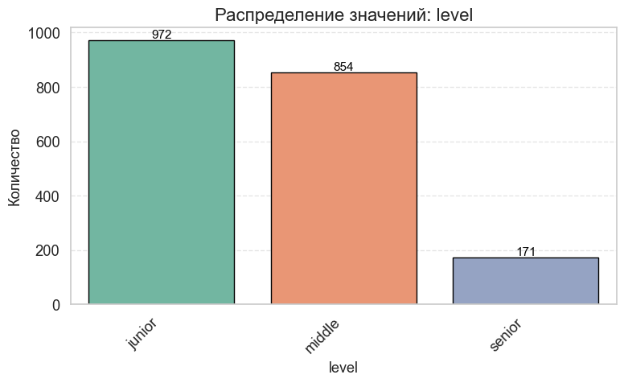

```
Категориальный признак: workload
```

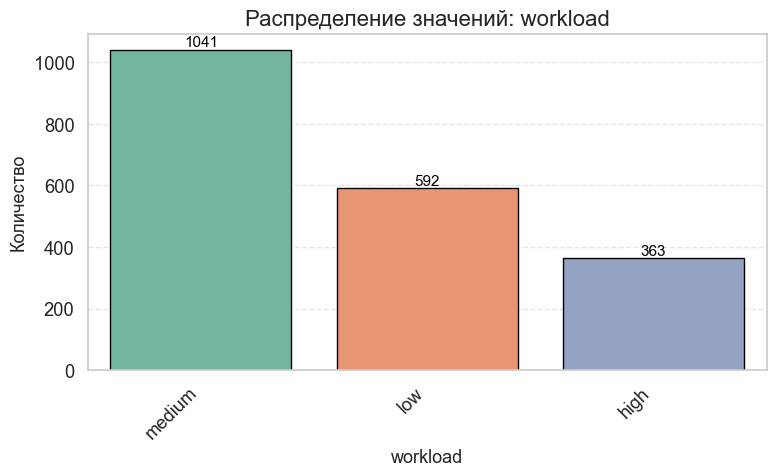

```
Категориальный признак: last_year_promo
```

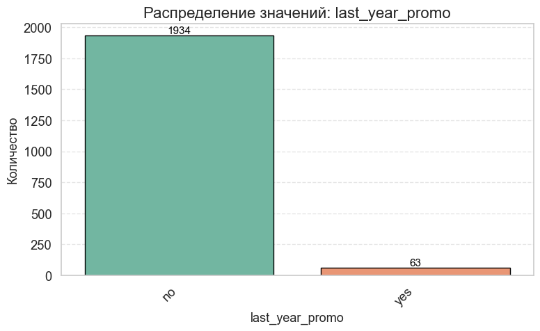

```
Категориальный признак: last_year_violations
```

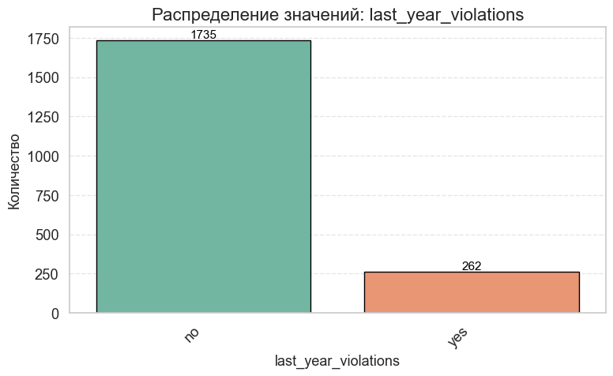

```
Таблица:  test_target_job_satisfaction_rate
```

```python
for table_name, df in dictionary_with_frames.items():
    print(big_bold_text('Таблица: '), table_name)

    cat_columns = df.select_dtypes(exclude='number').columns

    for col in cat_columns:
        print(f'\n{big_bold_text("Категориальный признак:")} {col}')

        # Подготовка данных
        value_counts = df[col].value_counts(dropna=False).reset_index()
        value_counts.columns = [col, 'count']

        num_categories = len(value_counts)
        fig_width = max(8, num_categories * 1.2)

        # Построение графика
        plt.figure(figsize=(fig_width, 5))
        ax = sns.barplot(data=value_counts, x=col, y='count', palette='Set2', edgecolor='black')
        plt.title(f'Распределение значений: {col}', fontsize=16)
        plt.xticks(rotation=45, ha='right')
        plt.xlabel(col, fontsize=13)
        plt.ylabel('Количество', fontsize=13)
        plt.grid(axis='y', linestyle='--', alpha=0.5)

        # Подписи над столбцами
        for p in ax.patches:
            height = int(p.get_height())
            ax.annotate(f'{height}',
                        (p.get_x() + p.get_width() / 2., height),
                        ha='center', va='bottom', fontsize=11, color='black')

        plt.tight_layout()
        plt.show()
```

**Вывод**

Необходимые замены:

```python
train_job_satisfaction_rate['level'] = train_job_satisfaction_rate['level'].replace('sinior','senior')
test_features['level'] = test_features['level'].replace('sinior','senior')
```

```python
test_features['dept']= test_features['dept'].replace(' ',np.nan)
test_features['workload']= test_features['workload'].replace(' ',np.nan)
train_job_satisfaction_rate['dept']= train_job_satisfaction_rate['dept'].replace(' ',np.nan)
train_job_satisfaction_rate['workload']= train_job_satisfaction_rate['workload'].replace(' ',np.nan)
```

## Исследовательский анализ данных

Посмотрим на распределение числовых данных

```python
#Переопределим словарь соответствия фрейма и его имени
dictionary_with_frames ={
    'train_job_satisfaction_rate': train_job_satisfaction_rate,
    'test_features': test_features,
    'test_target_job_satisfaction_rate': test_target_job_satisfaction_rate
}
```

```python
for row in dictionary_with_frames:
    print(big_bold_text('Таблица: '),row)
    display(dictionary_with_frames[row].drop('id', axis = 1).describe())
    print('')
```

```
Таблица:  train_job_satisfaction_rate
```

|  | employment_years | supervisor_evaluation | salary | job_satisfaction_rate |
| --- | --- | --- | --- | --- |
| count | 4000.000000 | 4000.000000 | 4000.000000 | 4000.000000 |
| mean | 3.718500 | 3.476500 | 33926.700000 | 0.533995 |
| std | 2.542513 | 1.008812 | 14900.703838 | 0.225327 |
| min | 1.000000 | 1.000000 | 12000.000000 | 0.030000 |
| 25% | 2.000000 | 3.000000 | 22800.000000 | 0.360000 |
| 50% | 3.000000 | 4.000000 | 30000.000000 | 0.560000 |
| 75% | 6.000000 | 4.000000 | 43200.000000 | 0.710000 |
| max | 10.000000 | 5.000000 | 98400.000000 | 1.000000 |

```
Таблица:  test_features
```

|  | employment_years | supervisor_evaluation | salary |
| --- | --- | --- | --- |
| count | 2000.000000 | 2000.000000 | 2000.000000 |
| mean | 3.666500 | 3.526500 | 34066.800000 |
| std | 2.537222 | 0.996892 | 15398.436729 |
| min | 1.000000 | 1.000000 | 12000.000000 |
| 25% | 1.000000 | 3.000000 | 22800.000000 |
| 50% | 3.000000 | 4.000000 | 30000.000000 |
| 75% | 6.000000 | 4.000000 | 43200.000000 |
| max | 10.000000 | 5.000000 | 96000.000000 |

```
Таблица:  test_target_job_satisfaction_rate
```

|  | job_satisfaction_rate |
| --- | --- |
| count | 2000.00000 |
| mean | 0.54878 |
| std | 0.22011 |
| min | 0.03000 |
| 25% | 0.38000 |
| 50% | 0.58000 |
| 75% | 0.72000 |
| max | 1.00000 |

**Построим графики числовых данных**

```
Таблица:  train_job_satisfaction_rate
Наименование столбца:  employment_years
```

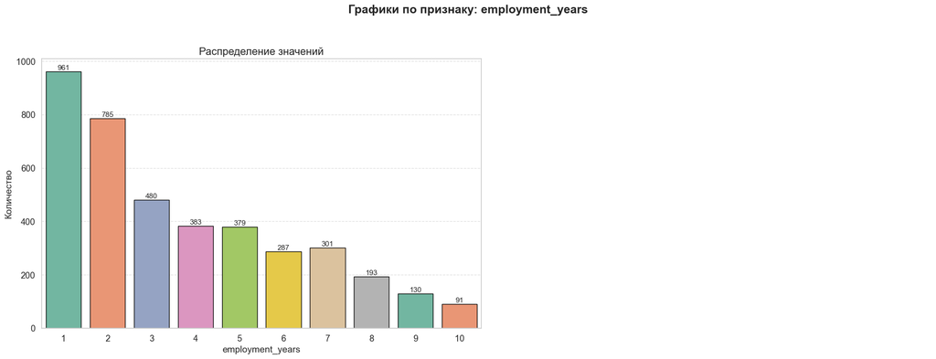

```
Наименование столбца:  supervisor_evaluation
```

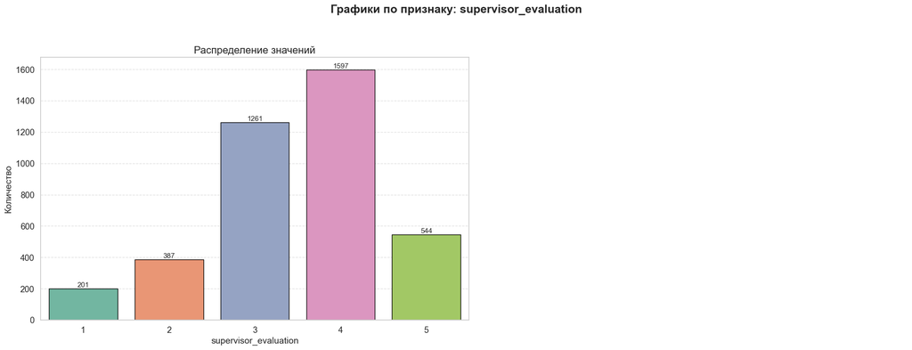

```
Наименование столбца:  salary
```

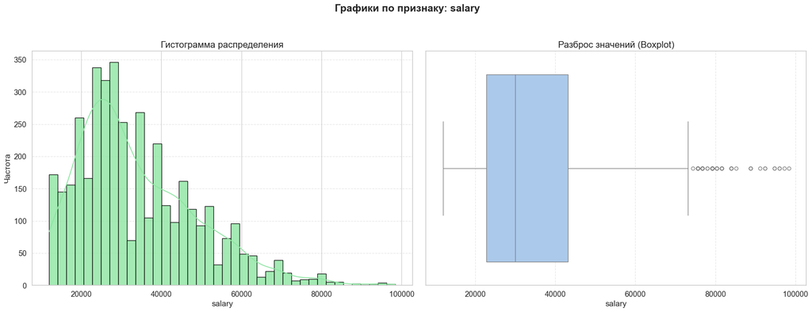

```
Наименование столбца:  job_satisfaction_rate
```

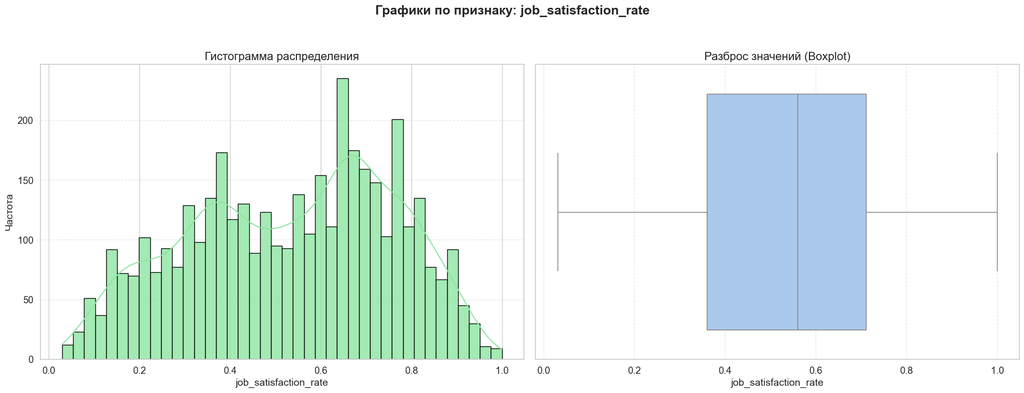

```
Таблица:  test_features
Наименование столбца:  employment_years
```

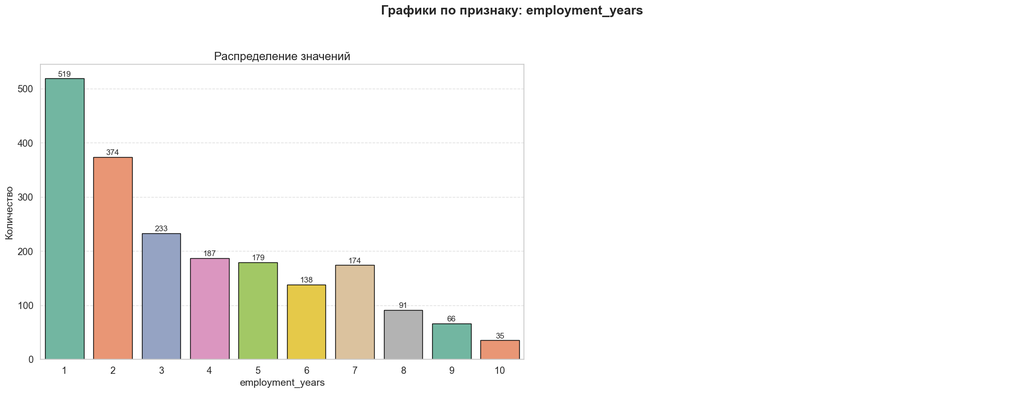

```
Наименование столбца:  supervisor_evaluation
```

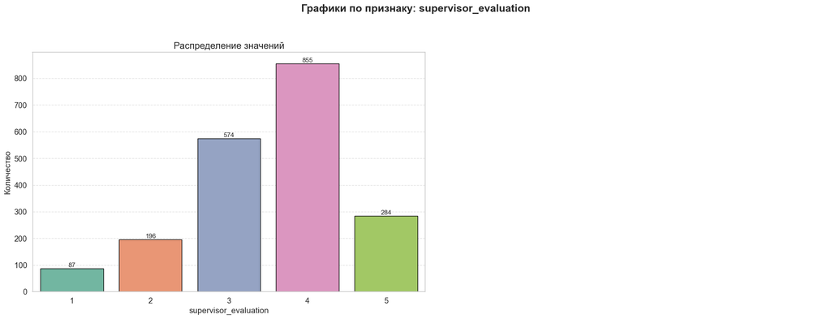

```
Наименование столбца:  salary
```

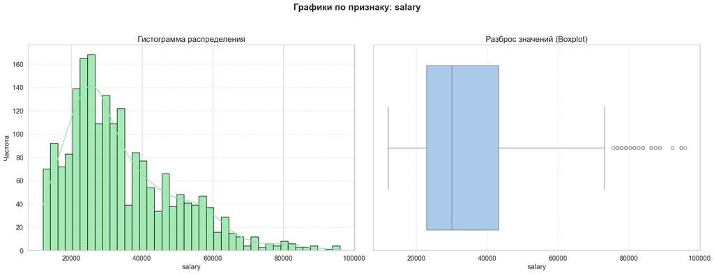

```
Таблица:  test_target_job_satisfaction_rate
Наименование столбца:  job_satisfaction_rate
```

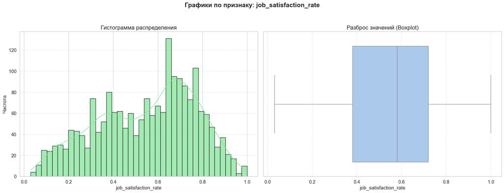

```python
# Устанавливаем стиль seaborn
sns.set(style='whitegrid', font_scale=1.2)

# Список дискретных признаков
discrete_columns = ['employment_years', 'supervisor_evaluation']

for table_name, df in dictionary_with_frames.items():
    print(big_bold_text('Таблица: '), table_name)

    # Получаем числовые столбцы (без 'id')
    numeric_cols = df.select_dtypes(include='number').columns.drop('id', errors='ignore')

    for column in numeric_cols:
        print(big_bold_text('Наименование столбца: '), column)

        fig, axes = plt.subplots(1, 2, figsize=(20, 8))
        fig.suptitle(f'Графики по признаку: {column}', fontsize=18, fontweight='bold')

        if column in discrete_columns:
            # Countplot для дискретных признаков
            ax = sns.countplot(data=df, x=column, ax=axes[0], palette='Set2', edgecolor='black')
            axes[0].set_title(f'Распределение значений', fontsize=16)
            axes[0].set_xlabel(column, fontsize=14)
            axes[0].set_ylabel('Количество', fontsize=14)
            axes[0].grid(True, axis='y', linestyle='--', alpha=0.6)

            # Добавляем подписи над столбцами
            for p in ax.patches:
                height = int(p.get_height())
                ax.annotate(f'{height}',
                            (p.get_x() + p.get_width() / 2., height + 1),
                            ha='center', va='bottom', fontsize=11)

            axes[1].axis('off')

        else:
            # Гистограмма для непрерывных признаков
            sns.histplot(data=df, x=column, bins=40, kde=True, ax=axes[0],
                         color=sns.color_palette('pastel')[2], edgecolor='black', alpha=0.8)
            axes[0].set_title('Гистограмма распределения', fontsize=16)
            axes[0].set_xlabel(column, fontsize=14)
            axes[0].set_ylabel('Частота', fontsize=14)
            axes[0].grid(True, axis='y', linestyle='--', alpha=0.5)

            # Boxplot
            sns.boxplot(data=df, x=column, ax=axes[1], palette='pastel', orient='h')
            axes[1].set_title('Разброс значений (Boxplot)', fontsize=16)
            axes[1].set_xlabel(column, fontsize=14)
            axes[1].grid(True, axis='x', linestyle='--', alpha=0.5)

        plt.tight_layout(rect=[0, 0.03, 1, 0.95])
        plt.show()
```

**Вывод:**

- Выбросы присутствуют, но они объясняются с точки зрения логики. Поэтому, удалять выбросы не нужно
- Больше всего данных о работниках с годом работы в компании
- Больше всего руководители ставят оценку 4 своим сотрудникам

**Вывод:**

1. В данных присутсвует большое количество специалистов из отдела продаж. Возможно, предсказание оттока из данной группы будет более точным, чем из остальных отделов
2. Позиций джун и мидл также значительно больше, чем специалистов сениор. Предсказания по первым двум позициям могут быть более точными

## Корреляционный анализ

```python
train_job_satisfaction_rate.head(5)
```

|  | id | dept | level | workload | employment_years | last_year_promo | last_year_violations | supervisor_evaluation | salary | job_satisfaction_rate |
| --- | --- | --- | --- | --- | --- | --- | --- | --- | --- | --- |
| 0 | 155278 | sales | junior | medium | 2 | no | no | 1 | 24000 | 0.58 |
| 1 | 653870 | hr | junior | high | 2 | no | no | 5 | 38400 | 0.76 |
| 2 | 184592 | sales | junior | low | 1 | no | no | 2 | 12000 | 0.11 |
| 3 | 171431 | technology | junior | low | 4 | no | no | 2 | 18000 | 0.37 |
| 4 | 693419 | hr | junior | medium | 1 | no | no | 3 | 22800 | 0.20 |

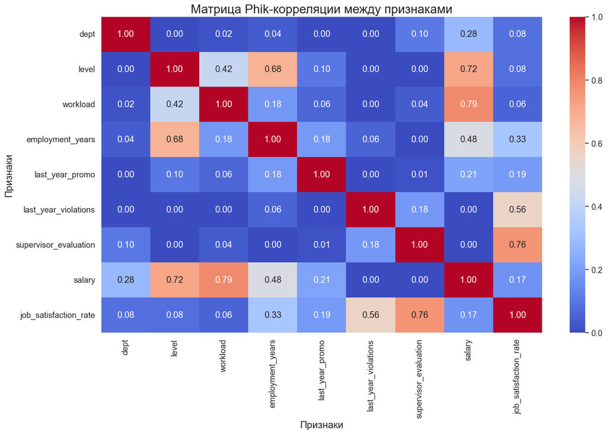

```python
# Предположим, что 'train_job_satisfaction_rate' — это DataFrame с данными
# Признаки, которые являются непрерывными
continuous_columns = ['job_satisfaction_rate', 'salary']

# Убираем столбец 'id' и рассчитываем матрицу Phik-корреляции
# Передаем список непрерывных признаков в параметр `interval_cols`
phik_matrix = train_job_satisfaction_rate.drop('id', axis=1).phik_matrix(interval_cols=continuous_columns)

# Построим тепловую карту
fig, ax = plt.subplots(figsize=(15, 10))
sns.heatmap(phik_matrix, annot=True, fmt='.2f', cmap='coolwarm', ax=ax)

# Добавляем заголовок и подписи к осям
ax.set_title('Матрица Phik-корреляции между признаками', fontsize=20)
ax.set_xlabel('Признаки', fontsize=16)
ax.set_ylabel('Признаки', fontsize=16)

plt.tight_layout()
plt.show()
```

**Вывод:**

## Использование пайплайнов

```python
train_job_satisfaction_rate = train_job_satisfaction_rate.dropna(subset=['dept', 'level']).reset_index(drop=True)
```

```python
id_drop = test_features.query('(dept.isnull() | level.isnull())')['id'].values
```

```python
test_features = test_features.loc[~(test_features['id'].isin(id_drop))].sort_values('id')
test_target_job_satisfaction_rate = test_target_job_satisfaction_rate.loc[~(test_target_job_satisfaction_rate['id'].isin(id_drop))].sort_values('id')
```

```python
len(test_features), len(test_target_job_satisfaction_rate), len(train_job_satisfaction_rate)
```

```
(1997, 1997, 3990)
```

```python
df = copy.deepcopy(train_job_satisfaction_rate)
X_train = df.drop(['id','job_satisfaction_rate'], axis=1)
y_train = df['job_satisfaction_rate'].values
```

```python
X_test = test_features.drop('id',axis = 1)
y_test = test_target_job_satisfaction_rate['job_satisfaction_rate'].values
```

```python
RANDOM_STATE = 42
```

```python
df_col = X_train.select_dtypes(include=np.number)
df_kach = X_train.select_dtypes(exclude=np.number)
```

```python
# создаём списки с названиями признаков
cat_columns = df_kach.columns
num_columns = df_col.columns
```

```python
# создаём списки с названиями признаков
ord_columns = ['level', 'workload']
ohe_columns = ['last_year_violations', 'last_year_promo', 'dept']
num_columns = ['employment_years', 'supervisor_evaluation', 'salary']
```

```python
def smape(y_true, y_pred):
    n = len(y_true)
    numerator = np.abs(y_true - y_pred)
    denominator = (np.abs(y_true) + np.abs(y_pred)) / 2
    summ = np.sum(numerator / denominator)
    smape_value = summ * (100 / n)
    return smape_value
```

```python
# Создаём обёртку для метрики MAPE
mape_scorer = make_scorer(smape, greater_is_better=False)
```

```python
ohe_pipe = Pipeline([
    ('simpleImputer_cat', SimpleImputer(strategy='most_frequent')),
    ('ohe', OneHotEncoder(drop='first', handle_unknown='ignore', sparse_output=False))
])

ordinal_pipe = Pipeline([
    ('simpleImputer_cat', SimpleImputer(strategy='most_frequent')),
    ('ordinal', OrdinalEncoder(categories=[['junior', 'middle', 'senior'], ['low', 'medium', 'high']],
                               handle_unknown='use_encoded_value', unknown_value=-1))
])

num_pipe = Pipeline([
    ('simpleImputer_num', SimpleImputer(strategy='median')),
    ('scaler', StandardScaler())  # меняется через RandomizedSearchCV
])

data_preprocessor = ColumnTransformer([
    ('num', num_pipe, num_columns),
    ('cat', ohe_pipe, ohe_columns),
    ('ord', ordinal_pipe, ord_columns)
])

pipe_final = Pipeline([
    ('clean_categories', CategoryCleaner(columns=['dept', 'workload'])),
    ('preprocessor', data_preprocessor),
    ('models', LinearRegression())
])

# =======================
# 5. Param Grid
# =======================
param_grid = [
    # словарь для модели KNeighborsRegressor()
    {
        'models': [KNeighborsRegressor()],  # Определение модели KNeighborsRegressor
        'models__n_neighbors': range(3, 10),  # Количество соседей для рассмотрения
        'models__weights': ['uniform', 'distance'],  # Тип весов для соседей
        'models__algorithm': ['auto', 'brute'],  # Алгоритм для поиска ближайших соседей
        'models__p': [1, 2],  # Параметр мощности для расстояния Минковского (манхэттенское и евклидово расстояние)
        'models__metric': ['euclidean', 'manhattan'],  # Метрика расстояния для вычисления ближайших соседей
        'preprocessor__num': [StandardScaler(), MinMaxScaler(), RobustScaler(), 'passthrough']
    },

    # словарь для модели DecisionTreeRegressor()
    {
        'models': [DecisionTreeRegressor(random_state=RANDOM_STATE)],
        'models__max_depth': range(2, 10),
        'models__max_features': range(2, 10),
        'preprocessor__num': [StandardScaler(), MinMaxScaler(), RobustScaler(), 'passthrough']
    },

        # словарь для модели LinearRegression()
    {
        'models' : [LinearRegression(n_jobs=-1)],
        'preprocessor__num': [StandardScaler(), MinMaxScaler(), 'passthrough']
    }

]

# =======================
# 6. Data Preparation
# =======================
df = copy.deepcopy(train_job_satisfaction_rate)
X_train = df.drop(['id','job_satisfaction_rate'], axis=1)
y_train = df['job_satisfaction_rate'].values
X_test = test_features.drop('id', axis=1)
y_test = test_target_job_satisfaction_rate['job_satisfaction_rate'].values

# =======================
# 7. Randomized Search
# =======================
random_search = RandomizedSearchCV(
    pipe_final,
    param_distributions=param_grid,
    n_iter=1000,
    cv=5,
    scoring=mape_scorer,
    random_state=42,
    n_jobs=-1
)

random_search.fit(X_train, y_train)

# =======================
# 8. Results
# =======================

# Выводим лучшую модель и её параметры
print('Лучшая модель и её параметры:\n\n', random_search.best_estimator_)
print('Лучший результат на кросс-валидации (SMAPE):', round(-random_search.best_score_))

# Предсказание и метрика на тестовой выборке
y_test_pred = random_search.predict(X_test)
print(f'Метрика SMAPE на тестовой выборке: {round(smape(y_test, y_test_pred))}')

# Извлекаем лучшие шаги пайплайна
best_estimator = random_search.best_estimator_
preprocessor = best_estimator.named_steps['preprocessor']

# Надёжное извлечение скейлера для числовых признаков
num_transformer = preprocessor.named_transformers_['num']
if hasattr(num_transformer, 'named_steps'):
    scaler = num_transformer.named_steps.get('scaler', 'No scaler step found')
else:
    scaler = num_transformer
print('Использованный скейлер для числовых признаков:', scaler)

# Проверка, какой кодировщик использован для категориальных признаков
cat_pipeline = preprocessor.named_transformers_['cat']
if hasattr(cat_pipeline, 'named_steps') and 'ohe' in cat_pipeline.named_steps:
    print('Использовался OneHotEncoder для категориальных признаков.')
elif hasattr(cat_pipeline, 'named_steps') and 'ordinal' in cat_pipeline.named_steps:
    print('Использовался OrdinalEncoder для категориальных признаков.')
else:
    print('Использовался другой метод обработки категориальных признаков:', cat_pipeline)

# =======================
# 9. Analysis of the importance of signs
# =======================

model = best_estimator.named_steps['models']

# Проверяем, поддерживает ли модель атрибут feature_importances_
if hasattr(model, 'feature_importances_'):
    # Получаем имена признаков из всех трансформеров
    num_features = preprocessor.transformers_[0][2]  # числовые
    cat_ohe = preprocessor.named_transformers_['cat'].named_steps['ohe']  # OneHotEncoder
    cat_features = cat_ohe.get_feature_names_out(preprocessor.transformers_[1][2]).tolist()  # категориальные
    ord_features = preprocessor.transformers_[2][2]  # порядковые

    # Объединяем все признаки
    all_features = num_features + cat_features + ord_features

    # Создаём таблицу важности признаков
    import pandas as pd
    importances = pd.Series(model.feature_importances_, index=all_features)

    print('\nВажность признаков (Feature Importances):')
    print(importances.sort_values(ascending=False))

    # (необязательно) можно визуализировать:
    importances.sort_values(ascending=False).plot(kind='bar', figsize=(12, 6), title='Feature Importances')
else:
    print('\nТекущая модель не поддерживает feature_importances_')
```

```
Лучшая модель и её параметры:

 Pipeline(steps=[('clean_categories',
                 CategoryCleaner(columns=['dept', 'workload'])),
                ('preprocessor',
                 ColumnTransformer(transformers=[('num', StandardScaler(),
                                                  ['employment_years',
                                                   'supervisor_evaluation',
                                                   'salary']),
                                                 ('cat',
                                                  Pipeline(steps=[('simpleImputer_cat',
                                                                   SimpleImputer(strategy='most_frequent')),
                                                                  ('ohe',
                                                                   OneHotEncoder(drop='first',
                                                                                 handle_unknown='ignore...
                                                  Pipeline(steps=[('simpleImputer_cat',
                                                                   SimpleImputer(strategy='most_frequent')),
                                                                  ('ordinal',
                                                                   OrdinalEncoder(categories=[['junior',
                                                                                               'middle',
                                                                                               'senior'],
                                                                                              ['low',
                                                                                               'medium',
                                                                                               'high']],
                                                                                  handle_unknown='use_encoded_value',
                                                                                  unknown_value=-1))]),
                                                  ['level', 'workload'])])),
                ('models',
                 KNeighborsRegressor(algorithm='brute', metric='manhattan',
                                     n_neighbors=9, p=1, weights='distance'))])
Лучший результат на кросс-валидации (SMAPE): 15
Метрика SMAPE на тестовой выборке: 14
Использованный скейлер для числовых признаков: StandardScaler()
Использовался OneHotEncoder для категориальных признаков.

Текущая модель не поддерживает feature_importances_
```

```python
# Получаем лучшую модель SVC
best_model = random_search.best_estimator_.named_steps['models']

# Выводим тип ядра, который был использован
print(f'Использованное ядро: {best_model}')
```

```
Использованное ядро: KNeighborsRegressor(algorithm='brute', metric='manhattan', n_neighbors=9, p=1,
                    weights='distance')
```

**Вывод:**

# Задача 2: предсказание увольнения сотрудника из компании

```python
train_quit  = pd.read_csv('train_quit.csv')
```

```python
test_target_quit = pd.read_csv('test_target_quit.csv')
```

```python
test_features = pd.read_csv('test_features.csv')
```

```python
#Создадим словарь соответствия фрейма и его имени
dictionary_with_frames ={
    'train_quit': train_quit,
    'test_features': test_features,
    'test_target_quit': test_target_quit
}
```

```python
for row in dictionary_with_frames:
    dictionary_with_frames[row].columns = dictionary_with_frames[row].columns.str.lower()
    dictionary_with_frames[row].columns = dictionary_with_frames[row].columns.str.replace(' ', '_', regex=True)
```

## Предобработка данных

```python
#Функция тестировани данных
def test_df (dictionary_with_frames_col):
    for row in dictionary_with_frames_col:
        print(big_bold_text('Таблица: '),row)
        print(big_bold_text('Количество дубликатов: '),dictionary_with_frames[row].duplicated().sum())
        if dictionary_with_frames[row].duplicated().sum()>0:
            print('')
            print(big_bold_text('Строки с дубликатами:'))
            display(dictionary_with_frames[row].loc[dictionary_with_frames[row].duplicated()==True])
        print('')
        print(big_bold_text('Информация по таблице\n'))
        dictionary_with_frames[row].info()
        print('')
        print(big_bold_text('Количество пропусков:\n'))
        print(dictionary_with_frames[row].isna().sum())
        print('')
        print(big_bold_text('Вывод первых 5 строк из таблицы\n'))
        display(dictionary_with_frames[row].head(5))
        print(big_bold_text('_____________________________________________________________________________________________________'))
        print('')
test_df(dictionary_with_frames)
```

```
Таблица:  train_quit
Количество дубликатов:  0

Информация по таблице

<class 'pandas.core.frame.DataFrame'>
RangeIndex: 4000 entries, 0 to 3999
Data columns (total 10 columns):
 #   Column                 Non-Null Count  Dtype
---  ------                 --------------  -----
 0   id                     4000 non-null   int64
 1   dept                   4000 non-null   object
 2   level                  4000 non-null   object
 3   workload               4000 non-null   object
 4   employment_years       4000 non-null   int64
 5   last_year_promo        4000 non-null   object
 6   last_year_violations   4000 non-null   object
 7   supervisor_evaluation  4000 non-null   int64
 8   salary                 4000 non-null   int64
 9   quit                   4000 non-null   object
dtypes: int64(4), object(6)
memory usage: 312.6+ KB

Количество пропусков:

id                       0
dept                     0
level                    0
workload                 0
employment_years         0
last_year_promo          0
last_year_violations     0
supervisor_evaluation    0
salary                   0
quit                     0
dtype: int64

Вывод первых 5 строк из таблицы
```

|  | id | dept | level | workload | employment_years | last_year_promo | last_year_violations | supervisor_evaluation | salary | quit |
| --- | --- | --- | --- | --- | --- | --- | --- | --- | --- | --- |
| 0 | 723290 | sales | middle | high | 2 | no | no | 4 | 54000 | no |
| 1 | 814010 | sales | junior | medium | 2 | no | no | 4 | 27600 | no |
| 2 | 155091 | purchasing | middle | medium | 5 | no | no | 1 | 37200 | no |
| 3 | 257132 | sales | junior | medium | 2 | no | yes | 3 | 24000 | yes |
| 4 | 910140 | marketing | junior | medium | 2 | no | no | 5 | 25200 | no |

[output not shown]

[output not shown]

```
_____________________________________________________________________________________________________

Таблица:  test_target_quit
Количество дубликатов:  0

Информация по таблице

<class 'pandas.core.frame.DataFrame'>
RangeIndex: 2000 entries, 0 to 1999
Data columns (total 2 columns):
 #   Column  Non-Null Count  Dtype
---  ------  --------------  -----
 0   id      2000 non-null   int64
 1   quit    2000 non-null   object
dtypes: int64(1), object(1)
memory usage: 31.4+ KB

Количество пропусков:

id      0
quit    0
dtype: int64

Вывод первых 5 строк из таблицы
```

|  | id | quit |
| --- | --- | --- |
| 0 | 999029 | yes |
| 1 | 372846 | no |
| 2 | 726767 | no |
| 3 | 490105 | no |
| 4 | 416898 | yes |

```
_____________________________________________________________________________________________________
```

```
Таблица:  train_quit

Категориальный признак: dept
```

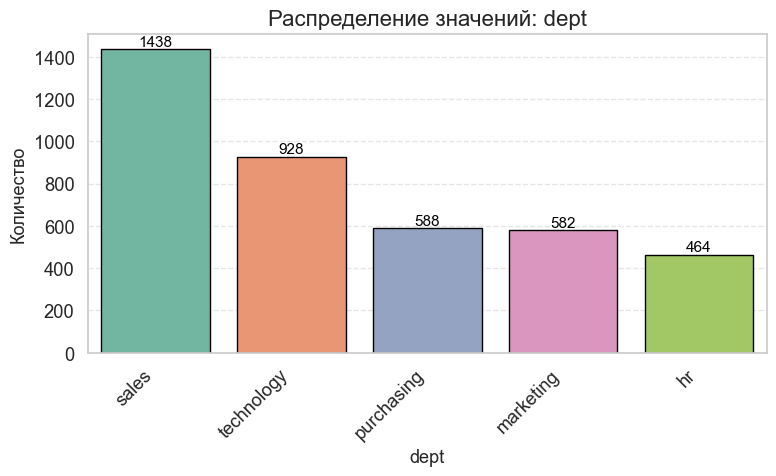

```
Категориальный признак: level
```

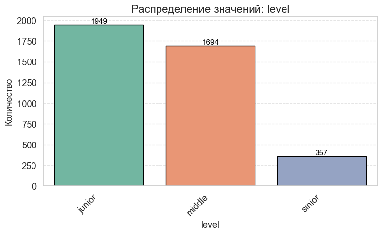

```
Категориальный признак: workload
```

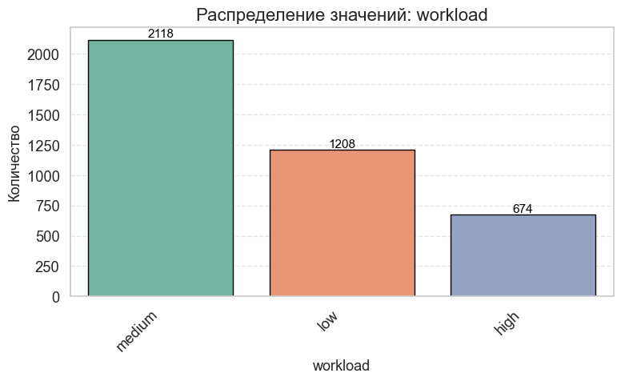

```
Категориальный признак: last_year_promo
```

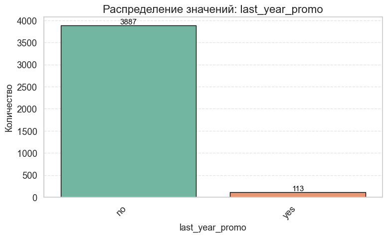

```
Категориальный признак: last_year_violations
```

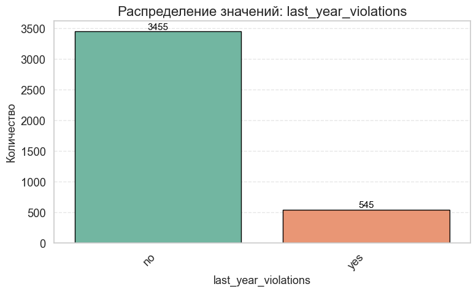

```
Категориальный признак: quit
```

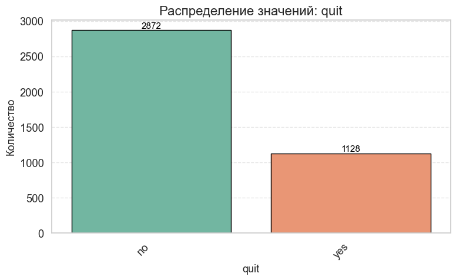

```
Таблица:  test_features

Категориальный признак: dept
```

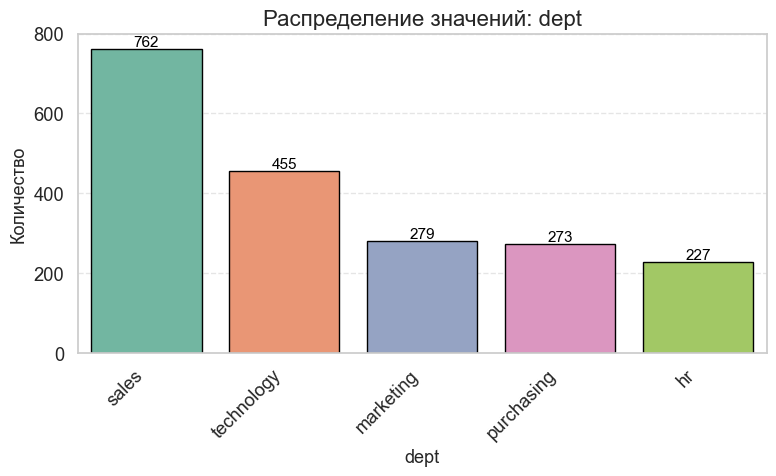

```
Категориальный признак: level
```

[figure not shown]

```
Категориальный признак: workload
```

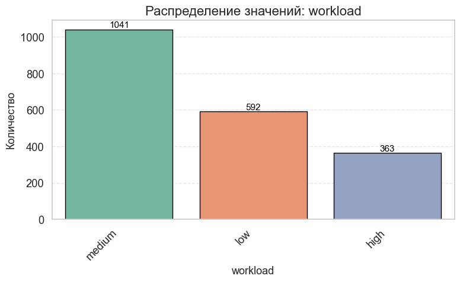

```
Категориальный признак: last_year_promo
```

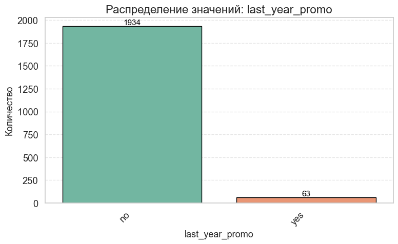

```
Категориальный признак: last_year_violations
```

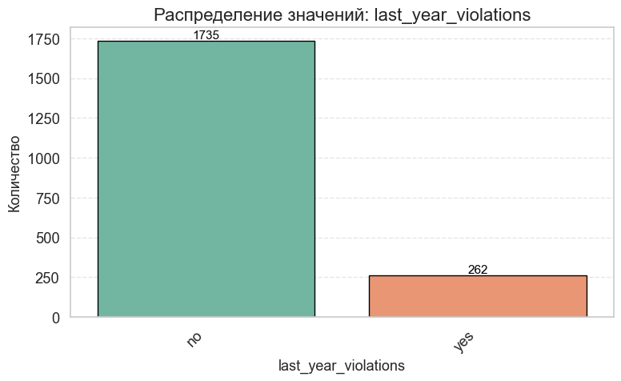

```
Таблица:  test_target_quit

Категориальный признак: quit
```

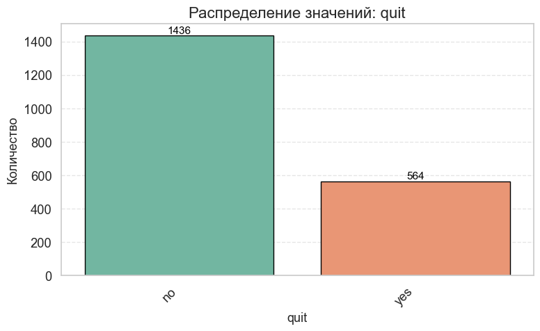

```python
for table_name, df in dictionary_with_frames.items():
    print(big_bold_text('Таблица: '), table_name)

    cat_columns = df.select_dtypes(exclude='number').columns

    for col in cat_columns:
        print(f'\n{big_bold_text("Категориальный признак:")} {col}')

        value_counts = df[col].value_counts(dropna=False).reset_index()
        value_counts.columns = [col, 'count']

        num_categories = len(value_counts)
        fig_width = max(8, num_categories * 1.2)

        plt.figure(figsize=(fig_width, 5))
        ax = sns.barplot(data=value_counts, x=col, y='count',
                         palette='Set2', edgecolor='black')

        plt.title(f'Распределение значений: {col}', fontsize=16)
        plt.xlabel(col, fontsize=13)
        plt.ylabel('Количество', fontsize=13)
        plt.xticks(rotation=45, ha='right')
        plt.grid(axis='y', linestyle='--', alpha=0.5)

        for p in ax.patches:
            height = int(p.get_height())
            ax.annotate(f'{height}',
                        (p.get_x() + p.get_width() / 2., height),
                        ha='center', va='bottom', fontsize=11, color='black')

        plt.tight_layout()
        plt.show()
```

```python
test_features['dept']= test_features['dept'].replace(' ',np.nan)
test_features['workload']= test_features['workload'].replace(' ',np.nan)
```

```python
test_features = test_features.loc[~(test_features['id'].isin(id_drop_2))].sort_values('id')
test_target_quit = test_target_quit.loc[~(test_target_quit['id'].isin(id_drop_2))].sort_values('id')
```

```python
train_quit['level'] = train_quit['level'].replace('sinior','senior')
test_features['level'] = test_features['level'].replace('sinior','senior')
```

```python
id_drop_3 = test_features.query('(dept.isnull() | level.isnull())')['id'].values
```

Удалим строки с отобранными id из двух выборок и сделаем сортировку по id, чтобы данные располагались в нужном порядке

```python
test_features = test_features.loc[~(test_features['id'].isin(id_drop_3))].sort_values('id')
test_target_quit = test_target_quit.loc[~(test_target_quit['id'].isin(id_drop_3))].sort_values('id')
```